# Infidelity, Relationship Satisfaction & Commitment, Age, and Marrying without Love

Author

Chandlyr Denaro

## Hypothesis 1

H1: Those who report a history of infidelity (categorical) will report lower relationship satisfaction/commitment (composite).

### Variables and descriptive statistics

- **History of Infidelity (`infidelity`):** A categorical variable with 2 groups: No Infidelity, Infidelity.
- **Composite of relationship satisfaction and commitment (`satisfaction_commitment`):** Mean of response to 6 questions regarding relationship satisfaction and commitment. Higher values indicate greater combined satisfaction and commitment.

```r
# Count respondents in each group.
table(h1Data$infidelity)
```

```
   Infidelity No Infidelity
        19050         31269
```

```r
# Summarize attractiveness points separately for each group.
by(h1Data$satisfaction_commitment, h1Data$infidelity, summary)
```

```
h1Data$infidelity: Infidelity
   Min. 1st Qu.  Median    Mean 3rd Qu.    Max.
  1.000   4.667   5.667   5.387   6.500   7.000
------------------------------------------------------------
h1Data$infidelity: No Infidelity
   Min. 1st Qu.  Median    Mean 3rd Qu.    Max.
  1.000   5.333   6.167   5.912   6.833   7.000
```

### Graph

Figure 1 shows the distribution combined relationship satisfaction and commitment by history of infidelity. The half-violin shows the shape of the distribution, the box summarizes the median and quartiles, and the dots represent individual responses.

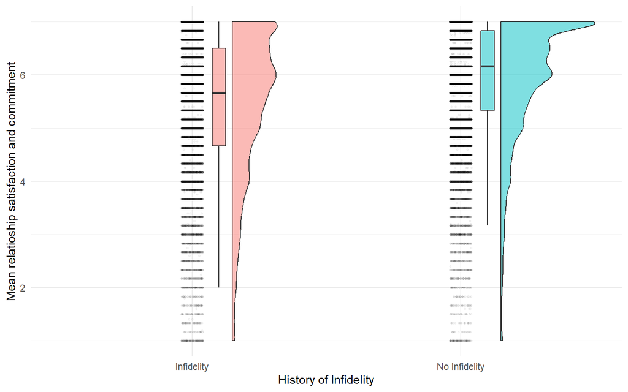

Figure 1: Combined relationship satisfaction and commitment, by history of infidelity.

```r
ggplot(h1Data, aes(x = infidelity, y = satisfaction_commitment,
                   fill = infidelity)) +
  geom_rain(alpha = 0.5, point.args = list(alpha = 0.04, size = 0.6)) +
  labs(x = "History of Infidelity", y = "Mean relatioship satisfaction and commitment") +
  theme_minimal() +
  theme(legend.position = "none")
```

## Hypothesis 2.

Willingness to marry without love will be negatively correlated with age.

### Variables and descriptive statistics

- **Age (`Age`):** A single demographic item about the respondents age. Responses range from 18 - 90.
- **Willingness to be get married without love (`Love_would_you_marry_1`):** A single response item about whether the responded would be willing to get married without being in love. Responses range from 0-100. 0 = Definitely not willing to be married without love, 100 = definitely willing to be married without love.

```r
summary(h2Data[, c("Age", "Love_would_you_marry_1")])
```

```
      Age        Love_would_you_marry_1
 Min.   :18.00   Min.   :  0.00
 1st Qu.:21.00   1st Qu.:  4.00
 Median :25.00   Median : 30.00
 Mean   :30.24   Mean   : 38.46
 3rd Qu.:36.00   3rd Qu.: 69.00
 Max.   :90.00   Max.   :100.00
```

### Graph

Figure 2 shows the relationship between age and willingness to marry without love. Points are jittered to make overlapping responses easier to see; the recorded scores are unchanged. The line summarizes the linear trend.

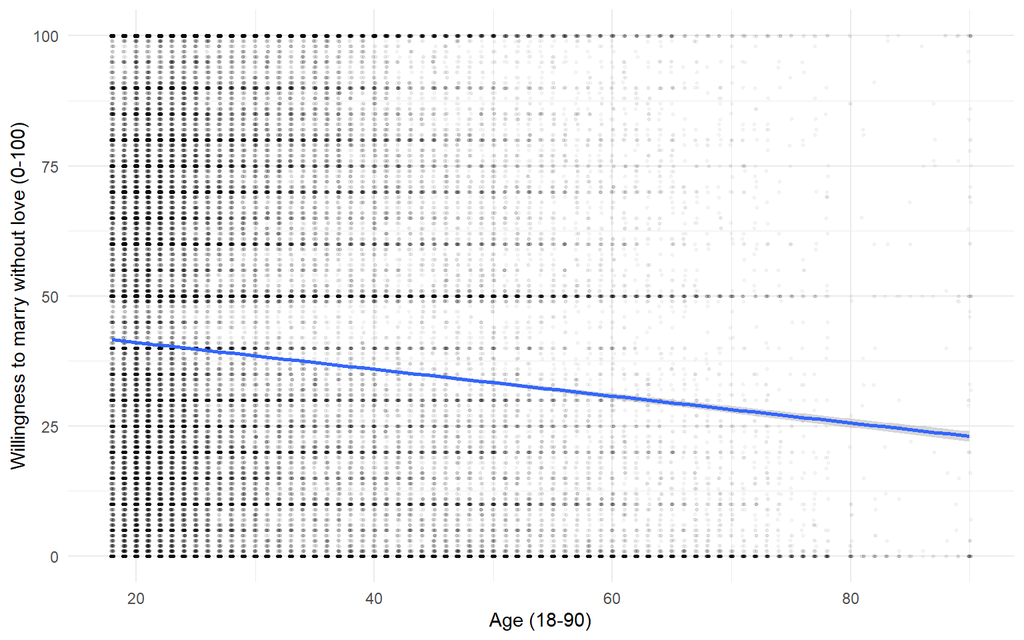

Figure 2: Willingness to marry without love across age.

```r
ggplot(h2Data, aes(x = Age, y = Love_would_you_marry_1)) +
  geom_jitter(width = .12, height = .04, alpha = .04, size = .6) +
  geom_smooth(method = "lm") +
  labs(x = "Age (18-90)",
       y = "Willingness to marry without love (0-100)") +
  theme_minimal()
```

### Observed trend

```r
r <- cor(h2Data$Age, h2Data$Love_would_you_marry_1, use = "complete.obs")
round(r, 2)
```

```
[1] -0.1
```

The correlation was -0.1, indicating a weak negative association. Older respondents reported less willingness to marry without love.